# Exploration of a MODIS SSES Dataset - Temperature Deficit

Chirag Kumar and Guillermo Podesta

# Prep Workspace and Data

We use MODIS matchups from 2002 - 2016 that have been read in through a previous script. Here we simply load the matchups, any necessary packages, and define necessary functions.

The matchup file read in at a previous step is not filtered and contains too many variables. For the purpose of this analysis, we use only nighttime matchups with a quality of 0, 1, or 2 and only keep variables from the infrared channels we use.

```r
# Turn POSIXct objects to characters bc dplyr doesn't support POSIXct
AQUA$sat.timedate <- as.character(AQUA$sat.timedate)
```

# Increased Spread of Residuals at Higher Buoy SSTs

We are interested in exploring the combinations of geophysical conditions that impact residual magnitude. For starters, we plot the buoy SST against the SST residual.

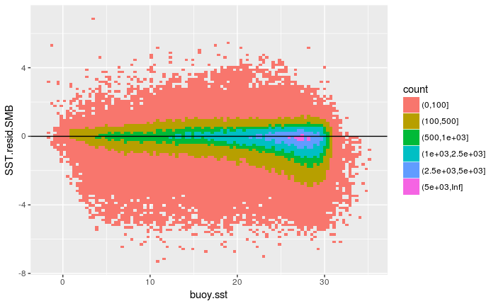

```r
ccc = RColorBrewer::brewer.pal(n = 8, 'YlOrRd')
ccc <- ccc[3:8]
ggplot2::ggplot(data = orig, mapping = aes(x = buoy.sst, y = SST.resid.SMB,
  fill = cut(..count.., c(0, 100, 500, 1000, 2500, 5000, Inf)))) +
  geom_bin2d(bins = 100) +
  #scale_fill_gradientn(colours = ccc) +
  scale_fill_hue('count') +
  geom_abline(slope = 0, intercept = 0, col = 'black')
```

We see that for higher buoy SST values, the spread and magnitude of the residuals increases. At, say, 25 deg C this trend becomes even more evident where there is a clump of retrievals around residual = -2. We demonstrate that observation with the following statistics.

```r
residuals_buoy_sst_lm <- lm(SST.resid.SMB ~ buoy.sst, data = orig)
cutoff <- 23
summary(orig$SST.resid.SMB[orig$buoy.sst < cutoff])
```

```
   Min. 1st Qu.  Median    Mean 3rd Qu.    Max.
-7.2550 -0.3650 -0.0450 -0.1228  0.2250  6.8950
```

```r
summary(orig$SST.resid.SMB[orig$buoy.sst >= cutoff])
```

```
   Min. 1st Qu.  Median    Mean 3rd Qu.    Max.
-6.9800 -0.6150 -0.1900 -0.3216  0.1150  5.1650
```

```r
IQR(orig$SST.resid.SMB[orig$buoy.sst < cutoff])
```

```
[1] 0.59
```

```r
IQR(orig$SST.resid.SMB[orig$buoy.sst >= cutoff])
```

```
[1] 0.73
```

We see very clearly that the spread and magnitude of the residual increases as the buoy SST increases. This trend becomes fairly evident at an SST of over 23 degrees Celsius. We now explore the nature of this increase and hypothesize to what may cause it.

In terms of identifying SST retrievals of varying residual magnitudes, figuring out what causes this spread and magnitude increase would enable us to identify those retrievals.

# Atmospheric Absorption at Warmer SSTs

The Clausius-Clapeyron equation says that as temperature increases, the atmosphere can hold more water vapor. The temperature deficit is a measure of atmospheric absorption so we should see it increase with SST.

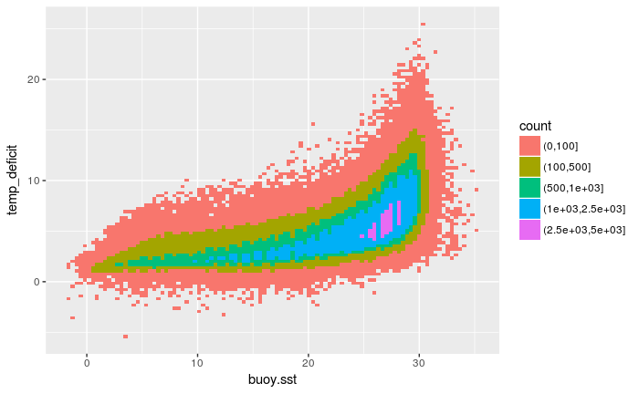

```r
ccc = RColorBrewer::brewer.pal(n = 8, 'YlOrRd')
ccc <- ccc[3:8]
temp_deficit <- orig$buoy.sst - orig$T_11
ggplot2::ggplot(data = orig, mapping = aes(x = buoy.sst, y = temp_deficit,
  fill = cut(..count.., c(0, 100, 500, 1000, 2500, 5000, Inf)))) +
  geom_bin2d(bins = 100) +
  scale_fill_hue('count')
```

```r
  #scale_fill_gradientn(colours = ccc)
```

We have now observed, in multiple forms, that the residuals and temperature deficit increase in spread and magnitude as the buoy SST increases.

We use the band.diff (T_11 - T_12) as a proxy for atmospheric absorption. Because atmospheric absorption increases at higher SSTs, we should also see band.diff increase at higher SSTs.

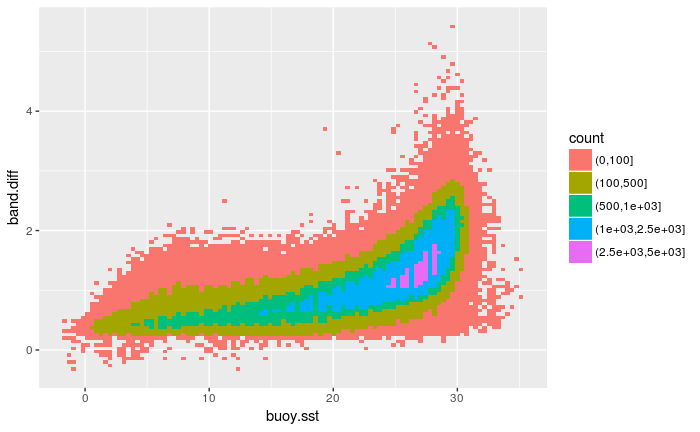

```r
ccc = RColorBrewer::brewer.pal(n = 8, 'YlOrRd')
ccc <- ccc[3:8]
ggplot2::ggplot(data = orig, aes(x = buoy.sst, y = band.diff,
  fill = cut(..count.., c(0, 100, 500, 1000, 2500, 5000, Inf)))) +
  geom_bin2d(bins = 100) +
  scale_fill_hue('count')
```

```r
  #scale_fill_gradientn(colours = ccc)
```

While band.diff does increase as SST increase in much of the same shape as temp_deficit increases with buoy SST, band.diff increases less implying that it becomes less responsive at higher SSTs! We can see this explicitly when we plot band.diff vs temp_deficit at SST greater than 23 degrees Celsius (a somewhat arbitrary value but we previously dubbed this our cutoff value.)

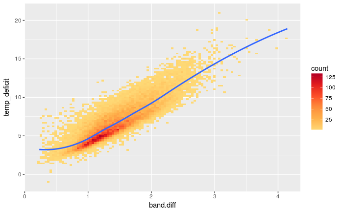

```r
ccc = RColorBrewer::brewer.pal(n = 8, 'YlOrRd')
ccc <- ccc[3:8]
#zz1 <- dplyr::tbl_df(orig) %>%
#  dplyr::filter(qsst == 0)
zz1 <- orig
cutoff_SST <- 23
temp_deficit <- zz1$buoy.sst - zz1$T_11
uuu <- data.frame(temp_deficit = temp_deficit[zz1$buoy.sst > 23], band.diff = zz1$band.diff[zz1$buoy.sst > 23])
# Take a sample of uuu bc loess requires lots of memory - for testing purposes
set.seed(42)
size <- 25000
index <- sample(1:nrow(uuu), size, replace = FALSE)
uuu <- uuu[index, ]
ggplot2::ggplot(data = uuu, aes(x = band.diff, y = temp_deficit)) +
  geom_bin2d(bins = 100) +
  scale_fill_gradientn(colours = ccc) +
  geom_smooth(method = 'loess', se = FALSE, span = 0.45)
```

```r
  #ggsave('band_diff_predictor_of_temp_deficit_different_in_situ_windows.pdf')
# Regression equations and statistics for the three facets
#uuu$temp_context_numeric <- factor(as.character(uuu$temp_context), labels = c(0, 1, 2), levels = c('(-Inf,10]', '(10,25]', '(25, Inf]'))
#temp_less_10_lm <- lm(formula = band.diff ~ temp_deficit, data = uuu[uuu$temp_context_numeric == 0, ])
#rSD_temp_less_10 <- IQR(temp_less_10_lm$residuals) / 1.348
#cor_temp_less_10 <- cor(uuu[uuu$temp_context_numeric == 0, 'temp_deficit'], uuu[uuu$temp_context_numeric == 0, 'band.diff'])
#temp_between_10_25_lm <- lm(formula = band.diff ~ temp_deficit, data = uuu[uuu$temp_context_numeric == 1, ])
#rSD_temp_between_10_25 <- IQR(temp_between_10_25_lm$residuals) / 1.348
#cor_temp_between_10_25 <- cor(uuu[uuu$temp_context_numeric == 1, 'temp_deficit'], uuu[uuu$temp_context_numeric == 1, 'band.diff'])
#temp_greater_25_lm <- lm(formula = band.diff ~ temp_deficit, data = uuu[uuu$temp_context_numeric == 2, ])
#rSD_temp_greater_25 <- IQR(temp_greater_25_lm$residuals) / 1.348
#cor_temp_greater_25 <- cor(uuu[uuu$temp_context_numeric == 2, 'temp_deficit'], uuu[uuu$temp_context_numeric == 2, 'band.diff'])
# Whole dataset for comparison
#temp_all_lm <- lm(formula = band.diff ~ temp_deficit, data = uuu)
#rSD_temp_all <- IQR(temp_all_lm$residuals) / 1.348
#cor_temp_all <- cor(uuu$temp_deficit, uuu$band.diff)
```

To correct for this lose in proportionality between the temperature deficit and band difference at higher temperatures, the NLSST algorithm “scales” the band.diff by the reference SST and the secant of the satellite zenith angle.

While these scaling measures help to create a term that is proportional to the temperature deficit at high SSTs, they do not completely fix the problem.

We plot the “re-scaled” band difference against the temperature deficit and there is still a loss of proportionality at high re-scaled band difference values. High re-scaled band difference values refer to those where the atmospheric absorption is high (we know there is an issue there) or when the reference SST is large (again, we know there is an issue there too.)

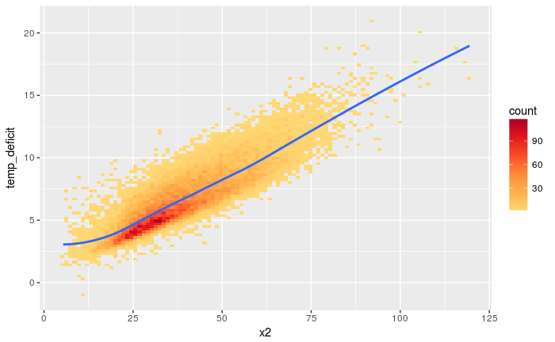

```r
ccc = RColorBrewer::brewer.pal(n = 8, 'YlOrRd')
ccc <- ccc[3:8]
#zz1 <- dplyr::tbl_df(orig) %>%
#  dplyr::filter(qsst == 0)
zz1  <- orig
cutoff_SST <- 23
temp_deficit <- zz1$buoy.sst - zz1$T_11
uuu <- data.frame(temp_deficit = temp_deficit[zz1$buoy.sst > 23], x2 = zz1$x2[zz1$buoy.sst > 23])
# Take a sample of uuu bc loess requires lots of memory - for testing purposes
set.seed(42)
size <- 25000
index <- sample(1:nrow(uuu), size, replace = FALSE)
uuu <- uuu[index, ]
ggplot2::ggplot(data = uuu, aes(x = x2, y = temp_deficit)) +
  geom_bin2d(bins = 100) +
  scale_fill_gradientn(colours = ccc) +
  geom_smooth(method = 'loess', se = FALSE, span = 0.45)
```

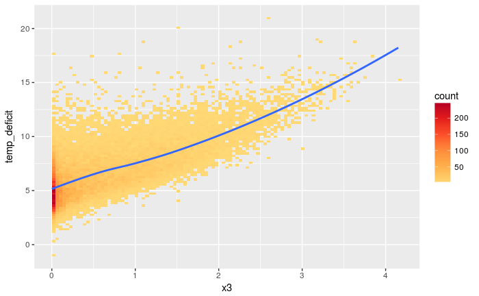

```r
ccc = RColorBrewer::brewer.pal(n = 8, 'YlOrRd')
ccc <- ccc[3:8]
#zz1 <- dplyr::tbl_df(orig) %>%
#  dplyr::filter(qsst == 0)
zz1 <- orig
cutoff_SST <- 23
temp_deficit <- zz1$buoy.sst - zz1$T_11
uuu <- data.frame(temp_deficit = temp_deficit[zz1$buoy.sst > 23], x3 = zz1$x3[zz1$buoy.sst > 23])
# Take a sample of uuu bc loess requires lots of memory - for testing purposes
set.seed(42)
size <- 25000
index <- sample(1:nrow(uuu), size, replace = FALSE)
uuu <- uuu[index, ]
ggplot2::ggplot(data = uuu, aes(x = x3, y = temp_deficit)) +
  geom_bin2d(bins = 100) +
  scale_fill_gradientn(colours = ccc) +
  geom_smooth(method = loess, se = FALSE, span = 0.45)
```

# Empirical Densities

We now try to identify the combinations of conditions that lead to the retrievals with a larger residual magnitude when SST is greater than 23 deg C. We use empirical density estimates as our visualization tool.

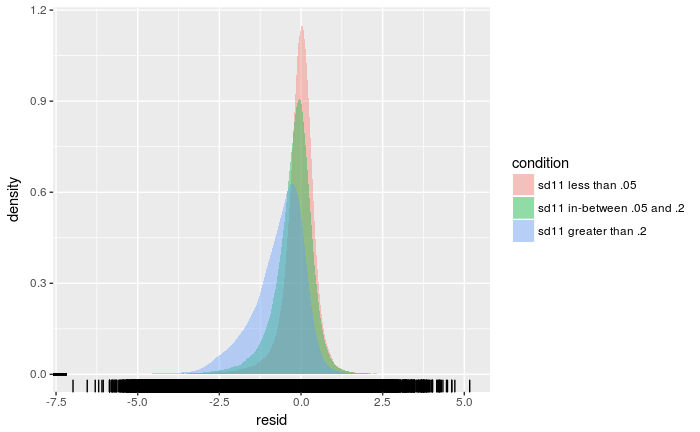

```r
qqq <- orig %>%
  dplyr::filter(buoy.sst >= 23)
ttt <- data.frame(condition = ifelse(qqq$sd11 > .05, ifelse(qqq$sd11 > .2, 2, 1), 0), resid = qqq$SST.resid.SMB)
ttt$condition <- factor(ttt$condition, levels = c(0, 1, 2), labels = c('sd11 less than .05', 'sd11 in-between .05 and .2', 'sd11 greater than .2'))
ggplot2::ggplot(data = ttt, aes(x = resid, fill = condition)) +
  geom_density(alpha = .4, color = NA) +
  geom_rug(aes(x = resid, y = 0), position = position_jitter(height = 0))
```

# Decision Trees

## Prep Data for Decision Trees

```r
# Filter dataframe so we are only dealing with retrievals with an SST of above cutoff

SST_cutoff <- 23

orig_filtered <- dplyr::tbl_df(orig) %>%
  dplyr::filter(buoy.sst > SST_cutoff)

# Make classes
class_resid <- cut(orig_filtered$SST.resid.SMB, breaks = c((min(orig_filtered$SST.resid.SMB)),
                                                -.4,
                                                .4,
                                                (max(orig$SST.resid.SMB + 0.01))),
                   labels = c('bad_low', 'good', 'bad_high'), include.lowest = TRUE)

#class_resid <- ifelse(orig$SST.resid.SMB > .2, 'resid > .2', ifelse(orig$SST.resid.SMB < -.2, 'resid < -.2', '-.2 <= resid <= .2'))
orig_filtered$class_resid <- as.factor(class_resid)
table(orig_filtered$class_resid)

orig_filtered %>% dplyr::group_by(class_resid) %>%
  dplyr::summarise(min = min(SST.resid.SMB), max = max(SST.resid.SMB))

# Divide data into training and validation sets
prop_train <- .6
len_train <- floor(prop_train * nrow(orig_filtered))
index <- sample(1:nrow(orig_filtered), len_train, replace = FALSE)

orig_filtered_train <- orig_filtered[index, ]
orig_filtered_test <- orig_filtered[-index, ]
```

### Rebalance Classes

```r
# making orig_train only have two classes - we remove one class
orig_filtered_train <- orig_filtered_train %>%
  dplyr::filter(class_resid != 'bad_high') %>%
  dplyr::select(-buoy.timedate)

orig_filtered_train$class_resid <- factor(orig_filtered_train$class_resid, levels = c('bad_low', 'good'))

# Do the same for orig_test
orig_filtered_test <- orig_filtered_test %>%
  dplyr::filter(class_resid != 'bad_high') %>%
  dplyr::select(-buoy.timedate)

orig_filtered_test$class_resid <- factor(orig_filtered_test$class_resid, levels = c('bad_low', 'good'))

# SMOTE

orig_filtered_train_smote <- DMwR::SMOTE(class_resid ~ ., as.data.frame(orig_filtered_train), perc.over = 100, perc.under = 200)

# ROSE

#orig_train_rose <- ROSE::ROSE(class_resid ~ ., as.data.frame(orig_train2), seed = 42)$data

# Now check out the class inbalance
table(orig_filtered_train$class_resid)

table(orig_filtered_train_smote$class_resid)
```

## RPart Decision Trees

```r
# Initialize data for the model
orig_filtered_train_smote$ref_SST_minus_T_11 <- orig_filtered_train_smote$ref_SST - orig_filtered_train_smote$T_11
orig_filtered_train_smote$ref_SST_minus_T_12 <- orig_filtered_train_smote$ref_SST - orig_filtered_train_smote$T_12

orig_filtered_test$ref_SST_minus_T_11 <- orig_filtered_test$ref_SST - orig_filtered_test$T_11
orig_filtered_test$ref_SST_minus_T_12 <- orig_filtered_test$ref_SST - orig_filtered_test$T_12
```

```r
clf_high_sst_smote <- rpart::rpart(formula = class_resid ~ T_11 + T_12 + band.diff + ref_SST + ref_SST_minus_T_11 + ref_SST_minus_T_12 + x2 +
    abs(satz) + range11 + sd11 + range12 + sd12 + x3,
                           data = orig_train2,
                           minbucket = 100,
                           xval = 5)
```